# SB Urchins (PELEGRI)

Patrick Pelegri-O’Day

10/23/2021

### Overview

In this document, data on urchin size and species collected from five sites along the Santa Barbara coast from 2008 to 2020 are wrangled and visualized. Size distribution of red and purple urchins are compared, and the trajectory of purple urchin counts over time are visualized and discussed.

**Data:** Reed, D. 2020. SBC LTER: Reef: Long-term experiment: Kelp removal: Urchin size frequency distribution ver 20. Environmental Data Initiative. https://doi.org/10.6073/pasta/5a1e9ef03aa47bd2225c0bb98a02a63b.

**Data description:** Data contain observations of red and purple urchins observed at 5 locations along the Santa Barbara coast. Data have been updated from their raw version for this assignment. See complete description and metadata [here](https://sbclter.msi.ucsb.edu/data/catalog/package/?package=knb-lter-sbc.26)

### Setup

Attach packages

```r
knitr::opts_chunk$set(echo = TRUE, warning = FALSE, message = FALSE)

library(tidyverse)
library(here)
library(janitor)
library(lubridate)
library(kableExtra)
```

Read in the data

```r
urchins <-
  read_csv(show_col_types = FALSE, here("data", "urchins.csv"))
```

### Initial data wrangling

Convert column names to lower_snake_case and convert date column to YYYY-MM-DD format and column class to “Date”

```r
urchins_clean <- # creating a new data frame called "urchins_clean"
  clean_names(urchins) %>% # applying `clean_names()` to convert column names to lower_snake_case
  mutate(date = mdy(date)) # replace original date column with new date column in YYYY-MM-DD format in which column class is "Date"
```

### Visually compare distribution of sizes between red and purple urchins

Create faceted histogram based on urchin size

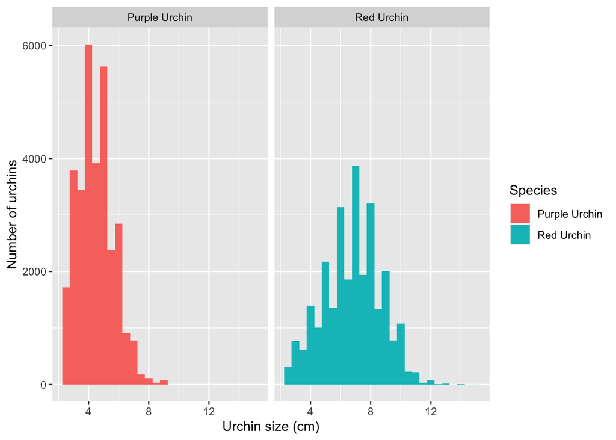

**Figure 1: Distribution of red and purple urchins by size in Santa Barbara.** The distribution of red and purple urchins by size (cm), rounded to the nearest 0.5cm, is displayed. Observations were taken at five sites along the Santa Barbara coast.

```r
ggplot(data = urchins_clean, aes(x = size, fill = common_name)) + # histogram will be based on urchin size; colors are according to species
  geom_histogram(binwidth = 0.5, bins = 10) + # use geom_histogram to create histogram
  facet_wrap(~common_name) + # use facet_wrap() to facet the histogram, here based on common_name
  labs(x = "Urchin size (cm)", y = "Number of urchins", fill = "Species")
```

### Summary table for red and purple urchins

Calculate summary statistics for red and purple urchins, then display results in a table

```r
urchins_stats <- urchins_clean %>% # start with urchins_clean
   group_by(common_name) %>% # group by species (using column common_name)
   summarize(mean = round(mean(size, na.rm = TRUE), 1), # find mean size and round to 1 decimal point
             sd = round(sd(size, na.rm = TRUE), 1), # find sd of size distribution and round to 1 decimal point
             median = median(size, na.rm = TRUE), # find median size
             sample_size = n() # count sample size
   )

kable(urchins_stats, # create table
      col = c("Species", "Mean Size (cm)", "Standard deviation", "Median Size (cm)", "Sample Size"), # assign column names
      caption = "Table 1: Summary statistics on size of purple and red urchins") %>%
  kable_styling(full_width = FALSE) # make table narrower
```

Table 1: Summary statistics on size of purple and red urchins

| Species | Mean Size (cm) | Standard deviation | Median Size (cm) | Sample Size |
| --- | --- | --- | --- | --- |
| Purple Urchin | 4.5 | 1.2 | 4.5 | 31805 |
| Red Urchin | 6.8 | 1.9 | 7.0 | 27408 |

**Takeaway:** Compared to the Red Urchins, The Purple Urchins have a smaller mean and median size, and a tighter spread. The Purple Urchins are quite a bit smaller. Their mean size is 2.3 cm smaller than the mean size of Red Urchins; in percentage terms the Purple Urchins are 34% smaller than the Red Urchins on average.

### Purple urchin counts by site and year

Wrangle data to only include purple urchin observations, and create new columns for year and full site name

```r
purple_urchins <- urchins_clean %>% # note that the date column in urchins_clean is already converted to class Date because of code in ### Initial data wrangling section
  filter(common_name == "Purple Urchin") %>% # retain only observations where common_name is Purple Urchin
  mutate(year = year(date)) %>% # create new column called year that contains the year, derived from the date column
  mutate(site_full = case_when( # add a new column site_full, which contains...
    site %in% c("NAPL") ~ "Naples Reef", # "Naples Reef" if site is "NAPL"
    site %in% c("AQUE") ~ "Arroyo Quemado Reef", # "Arroyo Quemado Reef" if site is "AQUE"
    site %in% c("CARP") ~ "Carpinteria Reef", # "Carpinteria Reef" if site is "CARP"
    site %in% c("MOHK") ~ "Mohawk Reef", # "Mohawk Reef" if site is "MOHK"
    site %in% c("IVEE") ~ "Isla Vista Reef", # "Isla Vista Reef" if site is "IVEE"
  ))
```

Store a table containing the total number of purple urchins observed by site and year.

```r
purple_urchin_stats <- purple_urchins %>%  # start from purple_urchins
  group_by(site_full, year) %>% # group by site (full name) and year
  summarize(population = n()) # count population
```

Make a graph of counts of purple urchins recorded at each site over time for the years included in the study. The graph below compares the purple urchin count at all sites on the same graph to get a sense of the trend for all sites as a whole.

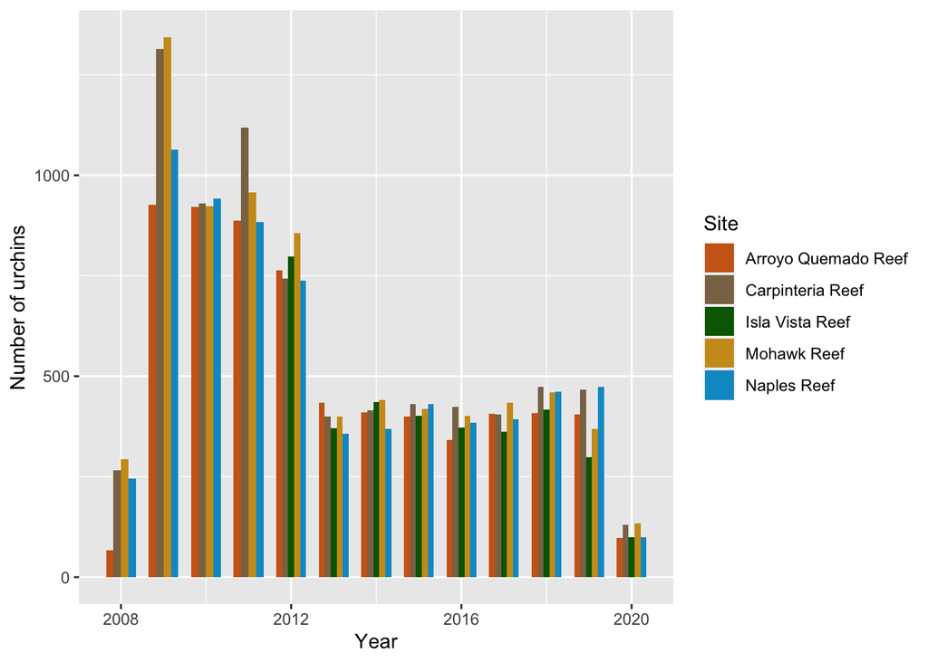

**Figure 2: Count of Purple Urchins in Santa Barbara.** This graph displays counts of purple urchins at five sites along the Santa Barbara coast with a single bar graph. The observation period spans 2008 to 2020.

```r
ggplot(purple_urchin_stats, # make a graph using purple_urchin_summary
       aes(x = year, # with year on the x-axis
           y = population, # and population on the y-axis
           fill = site_full)) + # set fill color of the bars to be based on the site the sample was drawn from
  geom_col(position = "dodge", width = 0.7) + # make it a bar graph. position = "dodge" sets the bars next to each other
  scale_fill_manual(values = c("Arroyo Quemado Reef" = "chocolate3", # set custom colors for each site
                                "Carpinteria Reef" = "burlywood4",
                                "Isla Vista Reef" = "darkgreen",
                                "Mohawk Reef" = "goldenrod3",
                                "Naples Reef" = "deepskyblue3")) +
  labs(x = "Year", y = "Number of urchins", fill = "Site", )
```

The graph below facets the purple urchin population count for each site into its own line graph so that trends for each site are more easily understood.

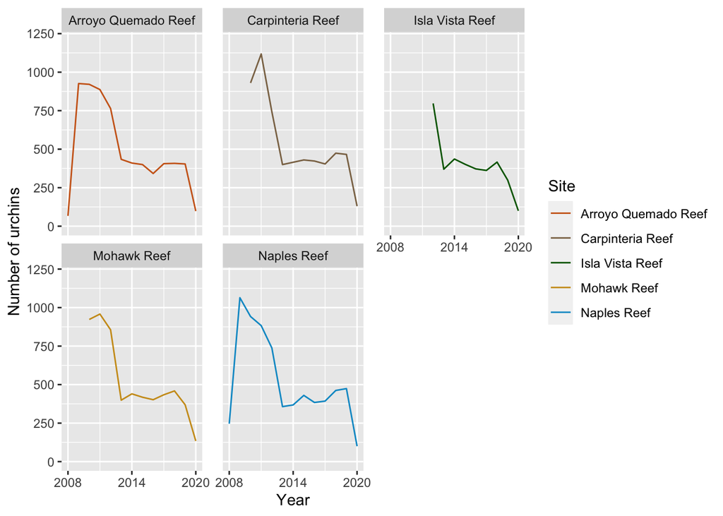

**Figure 3: Count of Purple Urchins in Santa Barbara.** This graph displays counts of purple urchins at five sites along the Santa Barbara coast through a series of faceted line graphs. The observation period spans 2008 to 2020.

```r
ggplot(purple_urchin_stats, # make a graph using purple_urchin_summary
       aes(x = year, # with year on the x-axis
           y = population, # and population on the y-axis
           color = site_full)) + # set line color to be based on the site the sample was drawn from
  geom_line() + # plot a line graph
  facet_wrap(~site_full) + # facet the graph by site_full
  theme(panel.spacing.x = unit(1, "lines")) + # space out panels horizontally
  scale_x_continuous(limits=c(2008,2020), breaks = c(2008, 2014, 2020)) + # customize x-axis scale to fit the graph size
  scale_y_continuous(limits=c(0,1200)) +
    scale_color_manual(values = c("Arroyo Quemado Reef" = "chocolate3", # set custom colors for each site to match the graph above
                                "Carpinteria Reef" = "burlywood4",
                                "Isla Vista Reef" = "darkgreen",
                                "Mohawk Reef" = "goldenrod3",
                                "Naples Reef" = "deepskyblue3")) +
  labs(x = "Year", y = "Number of urchins", color = "Site", )
```

**Takeaway:** This series of graphs shows a general decline in the population of purple urchins sampled at all five sites from 2009 to 2020. (For the sites where data were collected in 2008, there was a jump in urchin count from 2008 to 2009.) This does not necessarily mean that the actual populations have declined, however. If the sites were sampled in a consistent way over a large enough area, then we might conclude that the decline in the counted number of urchins represents a decline in the actual population of urchins in that area. If we counted in fewer places or different places as the years went on, or we had reason to believe that urchin populations were declining in the locations we sampled but staying steady or increasing in other areas within the site, then we might simply be counting fewer urchins even though the true size of the population is remaining constant or increasing.